# An Analysis of Music Genres and Their Danceability

Ivan Martinez-Kay

Daniel Nickas

Sandy Ge

08 August 2024

# Music Dataset : 1950 to 2019

## Introduction

Music is a core human experience, a fundamental part of our evolution. Music is an outlet for people to express and communicate with others. Some produce it and more consume and share it. It’s part of life that defines many people’s identities and helps to emphasize moods, whether uplifting or depressive, energetic or calming. The purpose in utilizing music data helps to understand how people’s behaviors over time are reflected and impact the music we hear. Though not necessarily simply a matter of change over time, we can discover what aspects are critical characteristics of each specific genre of music and its era of release through musical metadata. “There are several works involving musical lyrics and topic modeling, one in specific and very common used is the Latent Dirichlet Allocation (LDA) [Blei 2003]” (Misael, Luan, et al., 2020). LDA is a probabilistic model used to find latent semantic topics in collections of texts such as lyrics. We can cite the LyricsRadar [Sasaki 2014] which is a system based on latent topics of lyrics generated by LDA that enables a user to visualize the music topics interactively. LDA can also be applied to identify sentiments from songs through the lyrics just as audio analysis can [Sharma 2011, Dakshina 2013]. Using methods of creating data out of music using LDA provides a baseline for how we organize and characterize music for algorithms, such as one that you may see on Spotify. LDA is the start of how we can use statistical data to show how playlists are chosen by users, what features influence musical choices, and in some cases predict hits. Using audio data scrapped using Echo Nest® API integrated engine with spotipy Python’s package. The spotipy API permits the user to search for specific genres, artists, songs, release dates, etc. To obtain the lyrics we used the Lyrics Genius® API as base URL for requesting data based on the song title and artist name. Of the numerous song characteristics shown by the publicly available spotify based dataset, we chose to use a select few for in depth analysis in our quest to find what genres of music are most associated with dancing and danceability. Diving deeper, we wanted to understand what characteristics of a song made one more or less danceable.

The first step taken to begin the process of filtering of data from this public music data set, was to install the Rstudio packages and libraries shown below:

```r
# Set CRAN mirror and install necessary packages
options(repos = c(CRAN = "https://cran.rstudio.com"))

install.packages("evaluate")
install.packages("renv")
install.packages("tidyverse")
install.packages("ggplot2")
install.packages("dplyr")
install.packages("magrittr")
# Snapshot, restore, and hydrate renv environment
renv::snapshot()
```

```
- The lockfile is already up to date.
```

```r
renv::restore()
```

```
- The library is already synchronized with the lockfile.
```

```r
renv::hydrate()
```

```
- No new packages were discovered in this project; nothing to do.
```

```r
# Load necessary libraries
library(tidyverse)
library(readr)
library(ggplot2)
library(dplyr)
library(magrittr)
```

A preliminary step to filtering the data set is to test R and our music.csv file. This code snippet prints the first 6 observations, just to be sure we are working with the correct data set as R working directories may get crowded.

```r
install.packages("tidyverse")
library(tidyverse)
```

```r
library(readr)
music <- read_csv("/Users/ivanmartinez-kay/QTM-302W/Data/music.csv")
```

```
──────────────────────────────────────────────────────── Delimiter: "," chr
(5): artist_name, track_name, genre, lyrics, topic dbl (26): ...1,
release_date, len, dating, violence, world/life, night/time,...
```

```r
head(music)
```

| ...1 | artist_name | track_name | release_date | genre | lyrics | len | dating | violence | world/life | night/time | shake the audience | family/gospel | romantic | communication | obscene | music | movement/places | light/visual perceptions | family/spiritual | like/girls | sadness | feelings | danceability | loudness | acousticness | instrumentalness | valence | energy | topic | … |
| --- | --- | --- | --- | --- | --- | --- | --- | --- | --- | --- | --- | --- | --- | --- | --- | --- | --- | --- | --- | --- | --- | --- | --- | --- | --- | --- | --- | --- | --- | --- |
| 0 | mukesh | mohabbat bhi jhoothi | 1950 | pop | hold time feel break feel untrue convince speak voice tear try hold hurt try forgive okay play break string feel heart want feel tell real truth hurt lie worse anymore little turn dust play house ruin… | 95 | 0.0005980861 | 0.063746128 | 0.0005980862 | 0.0005980862 | 0.0005980861 | 0.048857015 | 0.017104339 | 0.263750881 | 0.0005980862 | 0.039288366 | 0.0005980862 | 0.0005980861 | 0.0005980861 | 0.0005980862 | 0.380298895 | 0.117175451 | 0.3577385 | 0.4541189 | 0.99799197 | 9.018219e-01 | 0.3394477 | 0.1371102 | sadness | … |
| 4 | frankie laine | i believe | 1950 | pop | believe drop rain fall grow believe darkest night candle glow believe go astray come believe believe believe smallest prayer hear believe great hear word time hear bear baby touch leaf believe believe… | 51 | 0.0355371338 | 0.096776742 | 0.4434351738 | 0.0012836971 | 0.0012836971 | 0.027007477 | 0.001283697 | 0.001283697 | 0.0012836971 | 0.118033841 | 0.0012836971 | 0.2126810672 | 0.0511241990 | 0.0012836971 | 0.001283697 | 0.001283697 | 0.3317448 | 0.6475399 | 0.95481923 | 1.528340e-06 | 0.3250206 | 0.2632403 | world/life | … |
| 6 | johnnie ray | cry | 1950 | pop | sweetheart send letter goodbye secret feel better wake dream think real false emotions feel heartaches hang long blue get bluer song remember cloudy hair | 24 | 0.0027700831 | 0.002770083 | 0.0027700833 | 0.0027700833 | 0.0027700831 | 0.002770083 | 0.158564466 | 0.250667910 | 0.0027700833 | 0.323794052 | 0.0027700835 | 0.0027700833 | 0.0027700833 | 0.0027700835 | 0.002770083 | 0.225422323 | 0.4562981 | 0.5852883 | 0.84036129 | 0.000000e+00 | 0.3518137 | 0.1391123 | music | … |
| 10 | pérez prado | patricia | 1950 | pop | kiss lips want stroll charm mambo chacha meringue heaven arm japan brag geisha care long uncle eye starry sort gleam like million dollar dream come true everybody wish steal heart away guess try eye s… | 54 | 0.0482491238 | 0.001547988 | 0.0015479877 | 0.0015479878 | 0.0215003555 | 0.001547988 | 0.411535825 | 0.001547988 | 0.0015479877 | 0.001547988 | 0.1292497849 | 0.0015479877 | 0.0015479876 | 0.0811317603 | 0.225889484 | 0.001547988 | 0.6869923 | 0.7444043 | 0.08393482 | 1.993927e-01 | 0.7753504 | 0.7437357 | romantic | … |
| 12 | giorgos papadopoulos | apopse eida oneiro | 1950 | pop | till darling till matter know till dream live apart know hearts till world free oceans cross mountains climb know gain loss pray loss time till dream till memory till hold till oceans cross mountains … | 48 | 0.0013495277 | 0.001349528 | 0.4177722727 | 0.0013495278 | 0.0013495277 | 0.001349528 | 0.463430095 | 0.001349528 | 0.0013495277 | 0.001349528 | 0.0013495277 | 0.0013495278 | 0.0297545651 | 0.0013495277 | 0.068800152 | 0.001349528 | 0.2916712 | 0.6464887 | 0.97590359 | 2.459514e-04 | 0.5970734 | 0.3943755 | romantic | … |
| 14 | perry como | round and round (with mitchell ayres and his orchestra & the ray charles singers) | 1950 | pop | convoy light dead ahead merchantmen trump diesels hammer oily kill grind knuckle white eye alight slam hatch deadly night cunning chicken lair hound hell devil care run silent run deep final prayer wa… | 98 | 0.0010526316 | 0.420684666 | 0.0010526316 | 0.0740782845 | 0.0010526316 | 0.001052632 | 0.001052632 | 0.001052632 | 0.0010526316 | 0.001052632 | 0.0010526316 | 0.1721731260 | 0.0010526316 | 0.0010526316 | 0.128291826 | 0.001052632 | 0.6891585 | 0.6855883 | 0.89859428 | 0.000000e+00 | 0.7681369 | 0.5495355 | violence | … |

A few more preliminary steps in testing R and confirming the csv file are functioning are to play around with the csv file.

```r
str(music)
```

```
spc_tbl_ [28,372 × 31] (S3: spec_tbl_df/tbl_df/tbl/data.frame)
 $ ...1                    : num [1:28372] 0 4 6 10 12 14 15 17 20 23 ...
 $ artist_name             : chr [1:28372] "mukesh" "frankie laine" "johnnie ray" "pérez prado" ...
 $ track_name              : chr [1:28372] "mohabbat bhi jhoothi" "i believe" "cry" "patricia" ...
 $ release_date            : num [1:28372] 1950 1950 1950 1950 1950 1950 1950 1950 1950 1950 ...
 $ genre                   : chr [1:28372] "pop" "pop" "pop" "pop" ...
 $ lyrics                  : chr [1:28372] "hold time feel break feel untrue convince speak voice tear try hold hurt try forgive okay play break string fee"| __truncated__ "believe drop rain fall grow believe darkest night candle glow believe go astray come believe believe believe sm"| __truncated__…
 $ len                     : num [1:28372] 95 51 24 54 48 98 179 21 30 61 ...
 $ dating                  : num [1:28372] 0.000598 0.035537 0.00277 0.048249 0.00135 ...
 $ violence                : num [1:28372] 0.06375 0.09678 0.00277 0.00155 0.00135 ...
 $ world/life              : num [1:28372] 0.000598 0.443435 0.00277 0.001548 0.417772 ...
 $ night/time              : num [1:28372] 0.000598 0.001284 0.00277 0.001548 0.00135 ...
 $ shake the audience      : num [1:28372] 0.000598 0.001284 0.00277 0.0215 0.00135 ...
 $ family/gospel           : num [1:28372] 0.04886 0.02701 0.00277 0.00155 0.00135 ...
 $ romantic                : num [1:28372] 0.0171 0.00128 0.15856 0.41154 0.46343 ...
 $ communication           : num [1:28372] 0.26375 0.00128 0.25067 0.00155 0.00135 ...
 $ obscene                 : num [1:28372] 0.000598 0.001284 0.00277 0.001548 0.00135 ...
 $ music                   : num [1:28372] 0.03929 0.11803 0.32379 0.00155 0.00135 ...
 $ movement/places         : num [1:28372] 0.000598 0.001284 0.00277 0.12925 0.00135 ...
 $ light/visual perceptions: num [1:28372] 0.000598 0.212681 0.00277 0.001548 0.00135 ...
 $ family/spiritual        : num [1:28372] 0.000598 0.051124 0.00277 0.001548 0.029755 ...
 $ like/girls              : num [1:28372] 0.000598 0.001284 0.00277 0.081132 0.00135 ...
 $ sadness                 : num [1:28372] 0.3803 0.00128 0.00277 0.22589 0.0688 ...
 $ feelings                : num [1:28372] 0.11718 0.00128 0.22542 0.00155 0.00135 ...
 $ danceability            : num [1:28372] 0.358 0.332 0.456 0.687 0.292 ...
 $ loudness                : num [1:28372] 0.454 0.648 0.585 0.744 0.646 ...
 $ acousticness            : num [1:28372] 0.998 0.9548 0.8404 0.0839 0.9759 ...
 $ instrumentalness        : num [1:28372] 9.02e-01 1.53e-06 0.00 1.99e-01 2.46e-04 ...
 $ valence                 : num [1:28372] 0.339 0.325 0.352 0.775 0.597 ...
 $ energy                  : num [1:28372] 0.137 0.263 0.139 0.744 0.394 ...
 $ topic                   : chr [1:28372] "sadness" "world/life" "music" "romantic" ...
 $ age                     : num [1:28372] 1 1 1 1 1 1 1 1 1 1 ...
 - attr(*, "spec")=
  .. cols(
  ..   ...1 = col_double(),
  ..   artist_name = col_character(),
  ..   track_name = col_character(),
  ..   release_date = col_double(),
  ..   genre = col_character(),
  ..   lyrics = col_character(),
```

[output cut: 12 more lines]

```
  ..   `light/visual perceptions` = col_double(),
  ..   `family/spiritual` = col_double(),
  ..   `like/girls` = col_double(),
  ..   sadness = col_double(),
  ..   feelings = col_double(),
  ..   danceability = col_double(),
  ..   loudness = col_double(),
  ..   acousticness = col_double(),
  ..   instrumentalness = col_double(),
  ..   valence = col_double(),
  ..   energy = col_double(),
  ..   topic = col_character(),
  ..   age = col_double()
  .. )
 - attr(*, "problems")=<externalptr>
```

```r
print(names(music))
```

```
 [1] "...1"                     "artist_name"
 [3] "track_name"               "release_date"
 [5] "genre"                    "lyrics"
 [7] "len"                      "dating"
 [9] "violence"                 "world/life"
[11] "night/time"               "shake the audience"
[13] "family/gospel"            "romantic"
[15] "communication"            "obscene"
[17] "music"                    "movement/places"
[19] "light/visual perceptions" "family/spiritual"
[21] "like/girls"               "sadness"
[23] "feelings"                 "danceability"
[25] "loudness"                 "acousticness"
[27] "instrumentalness"         "valence"
[29] "energy"                   "topic"
[31] "age"
```

```r
summary(music)
```

```
      ...1       artist_name         track_name         release_date
 Min.   :    0   Length:28372       Length:28372       Min.   :1950
 1st Qu.:20391   Class :character   Class :character   1st Qu.:1975
 Median :45406   Mode  :character   Mode  :character   Median :1991
 Mean   :42946                                         Mean   :1990
 3rd Qu.:64090                                         3rd Qu.:2007
 Max.   :82451                                         Max.   :2019
    genre              lyrics               len             dating
 Length:28372       Length:28372       Min.   :  1.00   Min.   :0.0002908
 Class :character   Class :character   1st Qu.: 42.00   1st Qu.:0.0009234
 Mode  :character   Mode  :character   Median : 63.00   Median :0.0014620
                                       Mean   : 73.03   Mean   :0.0211116
                                       3rd Qu.: 93.00   3rd Qu.:0.0040486
                                       Max.   :199.00   Max.   :0.6477057
    violence           world/life          night/time
 Min.   :0.0002845   Min.   :0.0002908   Min.   :0.0002892
 1st Qu.:0.0011198   1st Qu.:0.0011696   1st Qu.:0.0010320
 Median :0.0025063   Median :0.0065789   Median :0.0019493
 Mean   :0.1183964   Mean   :0.1209731   Mean   :0.0573871
 3rd Qu.:0.1926077   3rd Qu.:0.1977930   3rd Qu.:0.0658422
 Max.   :0.9817814   Max.   :0.9621053   Max.   :0.9736842
 shake the audience  family/gospel          romantic
 Min.   :0.0002845   Min.   :0.0002892   Min.   :0.0002845
 1st Qu.:0.0009930   1st Qu.:0.0009234   1st Qu.:0.0009747
 Median :0.0015949   Median :0.0015038   Median :0.0017544
 Mean   :0.0174224   Mean   :0.0170454   Mean   :0.0486810
 3rd Qu.:0.0100017   3rd Qu.:0.0047847   3rd Qu.:0.0423013
 Max.   :0.4974632   Max.   :0.5453030   Max.   :0.9407895
 communication          obscene              music
 Min.   :0.0002908   Min.   :0.0002892   Min.   :0.0002892
 1st Qu.:0.0011442   1st Qu.:0.0010526   1st Qu.:0.0009747
 Median :0.0026316   Median :0.0018149   Median :0.0018149
 Mean   :0.0766798   Mean   :0.0971679   Mean   :0.0600466
 3rd Qu.:0.1321360   3rd Qu.:0.0887652   3rd Qu.:0.0551005
 Max.   :0.6458294   Max.   :0.9922978   Max.   :0.9569378
 movement/places     light/visual perceptions family/spiritual
 Min.   :0.0002845   Min.   :0.0002845        Min.   :0.0002845
 1st Qu.:0.0009930   1st Qu.:0.0009930        1st Qu.:0.0009569
 Median :0.0016447   Median :0.0018149        Median :0.0016447
 Mean   :0.0474005   Mean   :0.0490049        Mean   :0.0241503
```

[output cut: 8 more lines]

```
 Max.   :0.5944587   Max.   :0.9814241   Max.   :0.9588101   Max.   :0.993502
    loudness       acousticness       instrumentalness       valence
 Min.   :0.0000   Min.   :0.0000003   Min.   :0.0000000   Min.   :0.0000
 1st Qu.:0.5954   1st Qu.:0.0342360   1st Qu.:0.0000000   1st Qu.:0.3291
 Median :0.6791   Median :0.2259028   Median :0.0000849   Median :0.5394
 Mean   :0.6652   Mean   :0.3392347   Mean   :0.0800490   Mean   :0.5329
 3rd Qu.:0.7490   3rd Qu.:0.6325298   3rd Qu.:0.0093345   3rd Qu.:0.7383
 Max.   :1.0000   Max.   :1.0000000   Max.   :0.9969636   Max.   :1.0000
     energy          topic                age
 Min.   :0.0000   Length:28372       Min.   :0.01429
 1st Qu.:0.3804   Class :character   1st Qu.:0.18571
 Median :0.5806   Mode  :character   Median :0.41429
 Mean   :0.5699                      Mean   :0.42519
 3rd Qu.:0.7728                      3rd Qu.:0.64286
 Max.   :1.0000                      Max.   :1.00000
```

A data set with so much qualitative data may be initially difficult to process, but if the qualitative data is assigned numerical values, analyzing the data can be done with concrete methodology that can be replicated. In order to quantify and assign values to a seemingly qualitative characteristic such as lyrical theme, the creators of the public data set used:

EQUATION 1: 1. similarity = cos(Θ) = ϕi · ϕj /(ϕi ϕj)

This equation would compute a number between 0 and 1 that would effectively act as a piece of raw data representing a lyrical characteristic or theme of a song. According to the creators of the data set:

“We evaluated the cosine distance, Eqn. (1), of words per topic using a 100-dimension GloVe word embedding [Pennington 2014] vector representation. To visualize the best number of words to represent each topic, we select every word proportion per topic k represented by ϕk distribution by the most frequent term in that topic to the rarest term.For each topic, we have chosen the first 10 words of ϕK and computed the cosine distance for every pair of their embedding vectors and stored the mean result in a variable gk,10. We repeated the same methodology for the first 11 to 25 words of ϕk in each topic k calculating the mean cosine distance of the word embeddings. Based on those criteria, we select an appropriate number of words to represent each topic that maximizes the mean cosine similarity. Each topic received a label based on the main subject of the selected words. A stop word list was used to exclude common English words. The stop word list used is built-in Scikit-learn.” (Misael, Luan, et al., 2020)

In our quest to find which songs and corresponding genres from the dataset were most danceable we considered a few song characteristics:

- Acousticness: Presence of acoustic instruments
- Danceability: how suitable a track is for dancing based on a combination of musical elements including tempo, rhythm stability, beat, strength, and overall regularity
- Loudness: The average loudness in decibels (dB) across the entire track
- Instrumentalness: A high value describes whether a track contains fewer vocals
- Valence: High (low) values means that the track is more happy, euphoric (sad, angry)
- Energy: Measures intensity and activity of music. Energetic tracks will be fast, loud and noisy Each characteristic as mentioned would be assigned a value between 0-1 based on equation 1 (shown above).

## Analysis

The code snippet just below is selecting specific columns from our initial music.csv data set and assigning them to a new data frame called “data” that includes only these selected columns (consisting of data necessary for this coding and analysis).

```r
# Trimming dataset for specific variables
data <- music[ ,c("genre", "loudness",
"danceability", "feelings", "instrumentalness", "acousticness",
"valence", "energy")]
```

In this small code chunk below, the median danceability by genre is found from the data set.

```r
median_danceability_by_genre <- data %>%
  group_by(genre) %>%
  summarise(median_danceability = median(danceability, na.rm = TRUE))

print(median_danceability_by_genre)
```

```
# A tibble: 7 × 2
  genre   median_danceability
  <chr>                 <dbl>
1 blues                 0.481
2 country               0.548
3 hip hop               0.748
4 jazz                  0.527
5 pop                   0.534
6 reggae                0.725
7 rock                  0.465
```

The first line is creating a data frame called “median_danceability_by_genre” from the “data” data frame and this pipe operator (%>%) allows the author to chain multiple functions together in a clear and readable way. The data frame data is passed to the next function in the chain. Then using the “group_by” function the data frame is grouped by the genre column. This means that subsequent operations will be performed separately for each genre. The 2nd to last line creates a new data frame containing summary statistics using “summmarise.” In this case, it will create one row per genre. “median(danceability, na.rm = TRUE)” will calculates the median of the danceability column for each genre group from the data set. The na.rm = TRUE argument ensures that any NA (missing) values are removed before calculating the median. Finally, the new data frame is printed, showing a 2 column chart with 7 rows. Each row should show a genre in one column with a corresponding median danceability score in the other.

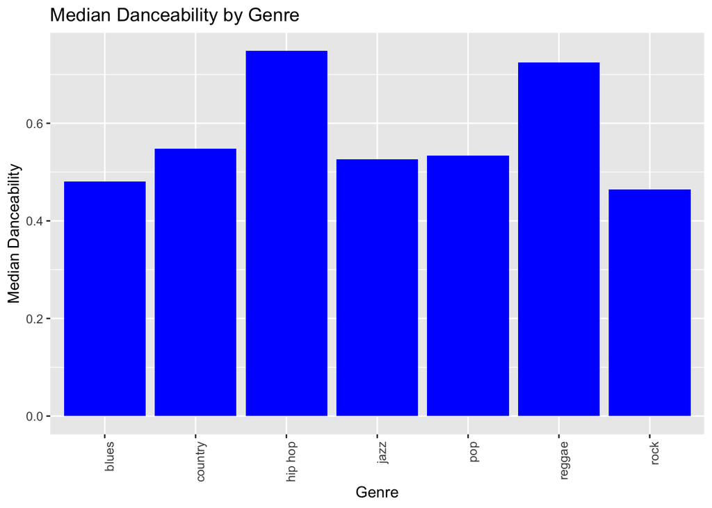

```r
# Bar chart of median danceability by genre
ggplot(median_danceability_by_genre, aes(x = genre, y = median_danceability)) +
  geom_bar(stat = "identity", fill = "blue") +
  theme(axis.text.x = element_text(angle = 90, hjust = 1)) +
  labs(title = "Median Danceability by Genre",
       x = "Genre",
       y = "Median Danceability")
```

From the above visualization, we notice that hiphop genre has the highest median danceability, closely followed by reggae, which is similar to what people would generally assume. The genre with the lowest danceability is rock, with the second lowest genre being blues. As blues is a rather slow genre, we are not surprised to see it ranked so low. However, rock, being such a rhythmic genre but ranking as the least danceable genre, is quite surprising to us.

# Feeling

Next, we mainly want to visualize median danceability by different values of feeling. To do so, we first need to calculate the median danceability by feeling, which is accomplished by the first three lines of the following code, where the first line initiates a pipeline for the dataset, the second line grouping the data by the feeling columns, and the third line calculating the median of the danceability column for each group of feelings. As a sidenote, the na.rm = TRUE argument ensures that any NA (missing) values in the danceability column are ignored during the median calculation. Then, the fourth line prints the median_danceability_by_feeling dataframe, which contains the median danceability values for each feeling. The subsequent calculations will follow suit.

```r
library(dplyr)

# Calculate median danceability by feeling
median_danceability_by_feeling <- data %>%
  group_by(feelings) %>%
  summarise(median_danceability = median(danceability, na.rm = TRUE))

print(median_danceability_by_feeling)
```

```
# A tibble: 28,087 × 2
   feelings median_danceability
      <dbl>               <dbl>
 1 0.000289               0.618
 2 0.000292               0.613
 3 0.000297               0.896
 4 0.000299               0.714
 5 0.000304               0.512
 6 0.000306               0.724
 7 0.000310               0.786
 8 0.000311               0.494
 9 0.000313               0.282
10 0.000313               0.739
# ℹ 28,077 more rows
```

With raw data, it is obviously very difficult to grasp what value or what range of values of feeling has the highest median danceability, which is why we separate the data into bins.

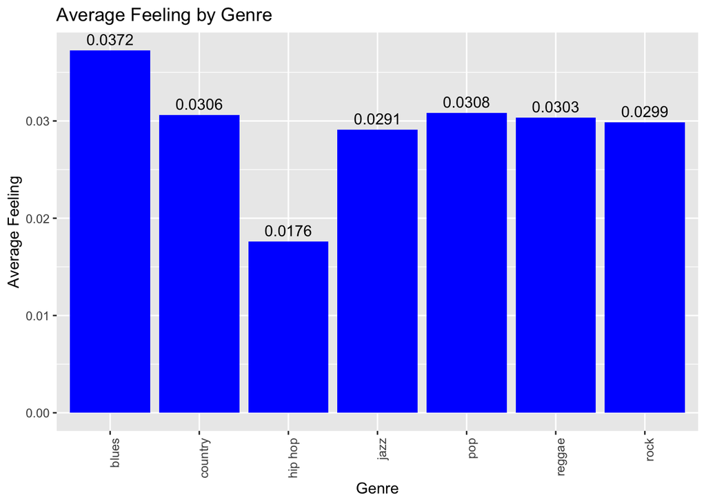

```r
library(dplyr)
library(ggplot2)

# Group data by genre, calculate average feeling
average_feeling_by_genre <- data %>%
  group_by(genre) %>%
  summarise(average_feeling = mean(feelings, na.rm = TRUE)) %>%
  ungroup()

ggplot(average_feeling_by_genre, aes(x = genre, y = average_feeling)) +
  geom_bar(stat = "identity", fill = "blue") +
  geom_text(aes(label = sprintf("%.4f", average_feeling)), vjust = -0.5, color = "black") +
  theme(axis.text.x = element_text(angle = 90, hjust = 1)) +
  labs(title = "Average Feeling by Genre",
       x = "Genre",
       y = "Average Feeling")
```

Here we can note that every single one of our genres fall into a range between 0.0 and 0.04, so for our purposes, we will filter the data and observe the behavior in this range.

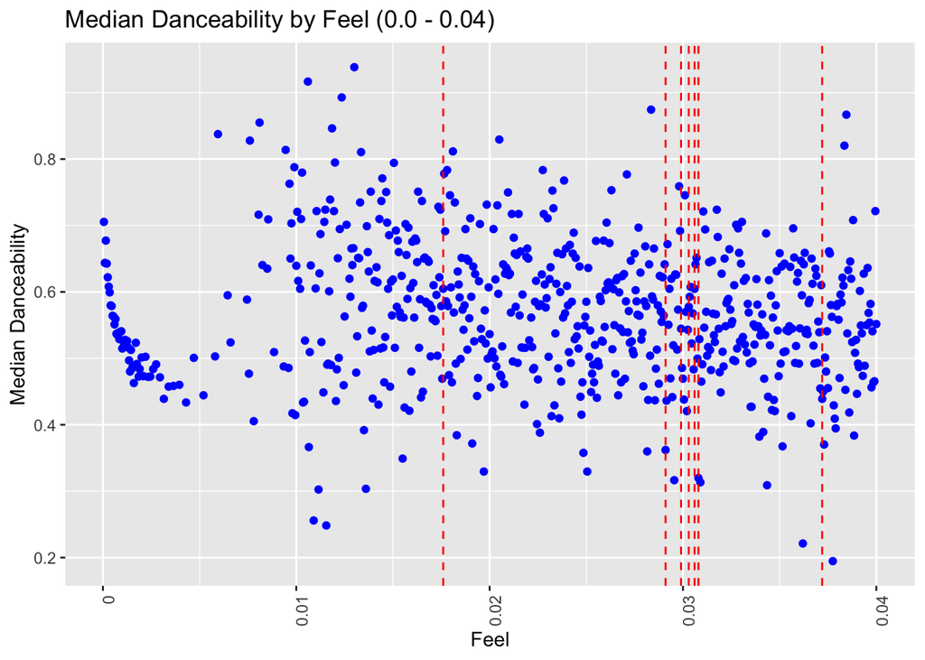

```r
library(readr)
library(dplyr)
library(ggplot2)

# Bins to condense data of musical feel
num_bins <- 20000
data <- data %>%
  mutate(feeling_bin = cut(feelings, breaks = num_bins, labels = FALSE))

# Calculate median danceability by feel of music
median_danceability_by_feeling_bin <- data %>%
  group_by(feeling_bin) %>%
  summarise(median_danceability = median(danceability, na.rm = TRUE))

# Convert feeling_bin to factor for plotting
median_danceability_by_feeling_bin <- median_danceability_by_feeling_bin %>%
  mutate(feeling_bin = as.numeric(as.character(feeling_bin)))

# Filter data to the range 0.0 - 0.04
filtered_data <- median_danceability_by_feeling_bin %>%
  filter(feeling_bin >= 0 & feeling_bin <= 0.04 * num_bins)

# Define the cutoff values and convert them to bin labels
cutoff_values <- c(0.0372, 0.0306, 0.0176, 0.0291, 0.0308, 0.0303, 0.0299)
cutoff_bins <- cutoff_values * num_bins

ggplot(filtered_data, aes(x = feeling_bin / num_bins, y = median_danceability)) +
  geom_point(color = "blue") +
  scale_x_continuous(
    breaks = seq(0, 0.04, by = 0.01),
    labels = seq(0, 0.04, by = 0.01)
  ) +
  theme(axis.text.x = element_text(angle = 90, hjust = 1)) +
  labs(title = "Median Danceability by Feel (0.0 - 0.04)",
       x = "Feel",
       y = "Median Danceability") +

  # Vertical lines at the cutoff values
  geom_vline(xintercept = cutoff_values, color = "red", linetype = "dashed")
```

We can observe that between 0.01 and 0.02 we find the most peaks in danceability. Hip hop lies in this range. Jazz cuts off just before 0.03 where there is a stiff dropoff, pointing to its lack of danceability. Blues also finds itself in a position just before a peak in danceability, but this is also the point where the drop is most notable (just before 0.04). Rock finds itself in an odd position, basically on the 0.03 line where there is a stiff dropoff and peak simultaneously; maybe we can use another metric for rock since it is the outlier. Country, reggae, and pop find themselves in a very similar region, but if you observe closely, reggae hits a peak just before pop and country drop off. So, rock remains our outlier for now. We will revisit this at the end.

# Instrumentality

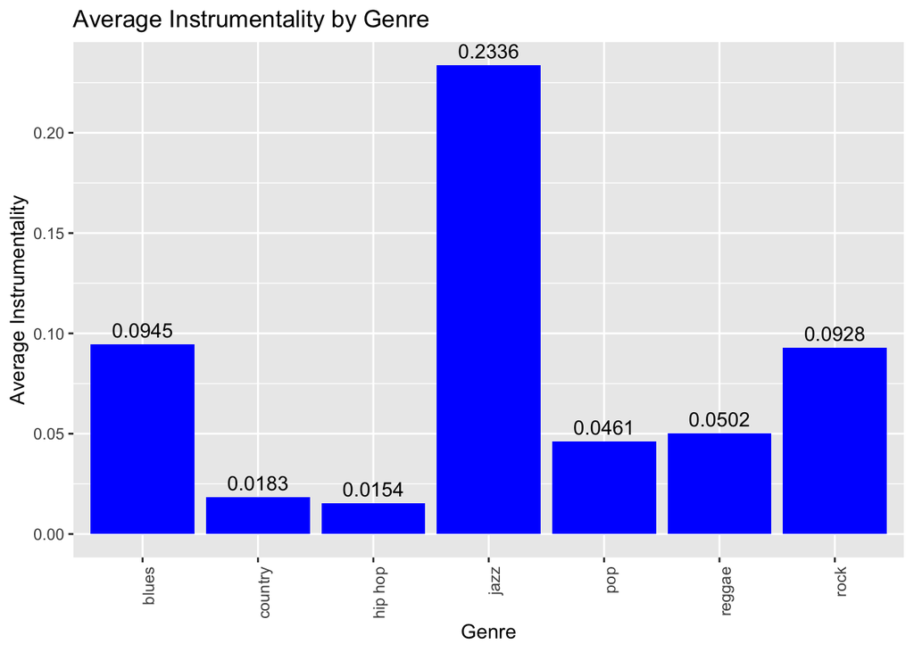

```r
library(dplyr)
library(ggplot2)

# Group data by genre, calculate average feeling
average_instrumentalness_by_genre <- data %>%
  group_by(genre) %>%
  summarise(average_instrumentalness = mean(instrumentalness, na.rm = TRUE)) %>%
  ungroup()

ggplot(average_instrumentalness_by_genre, aes(x = genre, y = average_instrumentalness)) +
  geom_bar(stat = "identity", fill = "blue") +
  geom_text(aes(label = sprintf("%.4f", average_instrumentalness)), vjust = -0.5, color = "black") +
  theme(axis.text.x = element_text(angle = 90, hjust = 1)) +
  labs(title = "Average Instrumentality by Genre",
       x = "Genre",
       y = "Average Instrumentality")
```

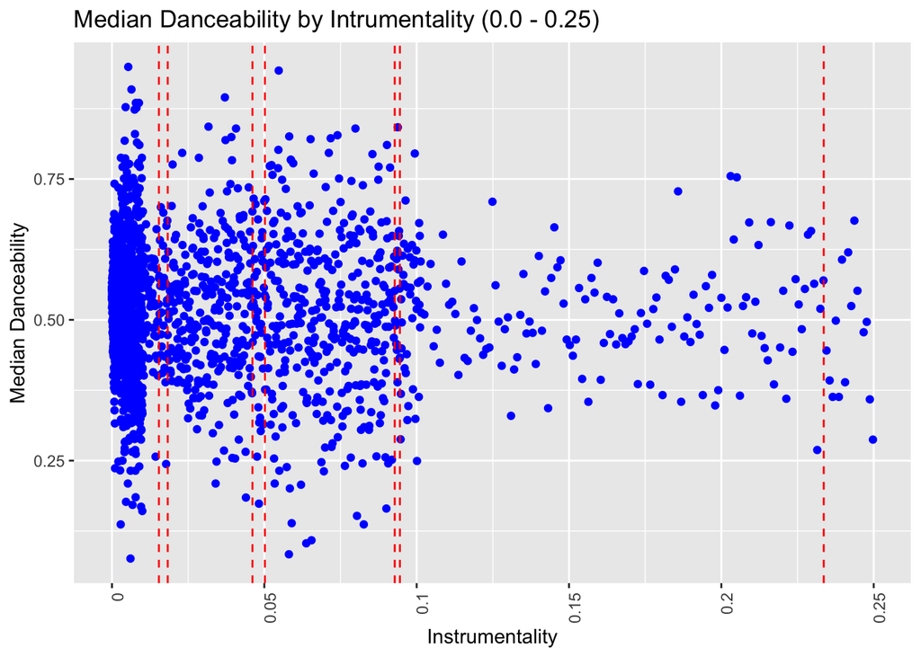

```r
library(readr)
library(dplyr)
library(ggplot2)

# Bins to condense data of musical feel
num_bins <- 200000
data <- data %>%
  mutate(instrumentalness_bin = cut(instrumentalness, breaks = num_bins, labels = FALSE))

# Calculate median danceability by feel of music
median_danceability_by_instrumentalness_bin <- data %>%
  group_by(instrumentalness_bin) %>%
  summarise(median_danceability = median(danceability, na.rm = TRUE))

# Convert feeling_bin to factor for plotting
median_danceability_by_instrumentalness_bin <- median_danceability_by_instrumentalness_bin %>%
  mutate(instrumentalness_bin = as.numeric(as.character(instrumentalness_bin)))

# Filter data to the range 0.0 - 0.25
filtered_data <- median_danceability_by_instrumentalness_bin %>%
  filter(instrumentalness_bin >= 0 & instrumentalness_bin <= 0.25 * num_bins)

# Cutoff values and convert them to bin labels
cutoff_values <- c(0.0945, 0.0183, 0.0154, 0.2336, 0.0461, 0.0502, 0.0928)
cutoff_bins <- cutoff_values * num_bins

ggplot(filtered_data, aes(x = instrumentalness_bin / num_bins, y = median_danceability)) +
  geom_point(color = "blue") +
  scale_x_continuous(
    breaks = seq(0, 0.25, by = 0.05),
    labels = seq(0, 0.25, by = 0.05)
  ) +
  theme(axis.text.x = element_text(angle = 90, hjust = 1)) +
  labs(title = "Median Danceability by Intrumentality (0.0 - 0.25)",
       x = "Instrumentality",
       y = "Median Danceability") +
  # Vertical lines at the cutoff values
  geom_vline(xintercept = cutoff_values, color = "red", linetype = "dashed")
```

We find that jazz finds its cutoff at a low point as suspected. What about blues and rock? Both pose as outliers in this case by encompassing a point that has both lows and peaks. that’s one confirmation for blues, but rock still remains the single inconsistency. Our leader, hip hop, finds itself on an downward slope near the origin (not quite a peak but still higher than others), while it’s follower country finds itself on a slight drop. One observation to note is that the danceability peaks near the origin, pointing to lower instrumentality being proportional to danceability. Reggae and op find themselves in the same scenario with reggae barely kissing a peak, and pop on a downward trend.

With this in mind, let’s synthesize the data and see what we get.

# Synthesis

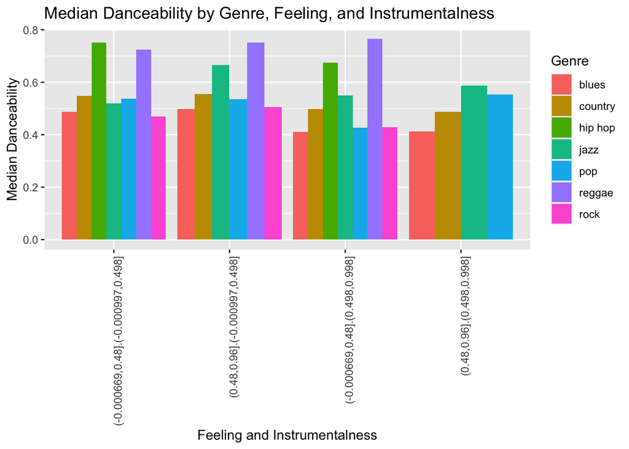

```r
# Bins for condensing data (feelings and instrumentalness variables)
num_bins_feelings <- 2
num_bins_instrumentalness <- 2

data <- data %>%
  mutate(feeling_bin = cut(feelings, breaks = num_bins_feelings),
         instrumentalness_bin = cut(instrumentalness,
         breaks = num_bins_instrumentalness))

# Calculate median danceability by genre, feelings bin, and instrumentalness bin
median_danceability_by_genre_feeling_instrumentalness <- data %>%
  group_by(genre, feeling_bin, instrumentalness_bin) %>%
  summarise(median_danceability = median(danceability, na.rm = TRUE))
#Synthesis chart
ggplot(median_danceability_by_genre_feeling_instrumentalness, aes(x = interaction(feeling_bin,
instrumentalness_bin), y = median_danceability, fill = genre)) +
  geom_bar(stat = "identity", position = "dodge") +
  theme(axis.text.x = element_text(angle = 90, hjust = 1)) +
  labs(title = "Median Danceability by Genre, Feeling, and Instrumentalness",
       x = "Feeling and Instrumentalness",
       y = "Median Danceability",
       fill = "Genre")
```

This graph synthesizes the information of the three previous bar charts. It once again demonstrates that even on a basis of feel and instumentality, reggae and hip hop still remain the most danceable before their respective cutoffs.

# Loudness

```r
library(dplyr)

# Calculate median danceability by decibel level
median_danceability_by_loudness <- data %>%
  group_by(loudness) %>%
  summarise(median_danceability = median(danceability, na.rm = TRUE))

print(median_danceability_by_loudness)
```

```
# A tibble: 13,066 × 2
   loudness median_danceability
      <dbl>               <dbl>
 1   0                    0.418
 2   0.0582               0.242
 3   0.0880               0.402
 4   0.101                0.236
 5   0.122                0.458
 6   0.125                0.573
 7   0.138                0.625
 8   0.145                0.371
 9   0.148                0.534
10   0.156                0.583
# ℹ 13,056 more rows
```

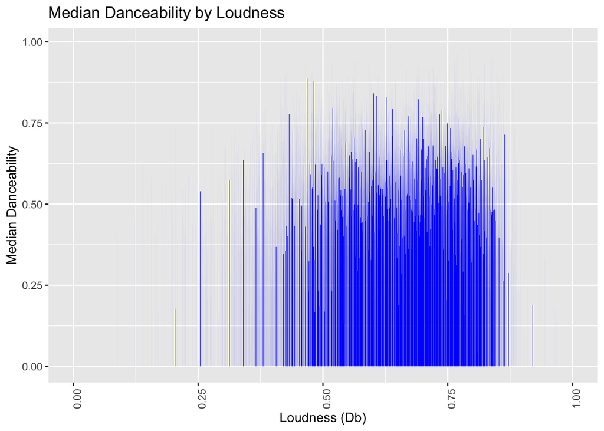

```r
library(readr)
library(ggplot2)

# Bar chart of median danceability by decibel level
ggplot(median_danceability_by_loudness, aes(x = loudness, y = median_danceability)) +
  geom_bar(stat = "identity", fill = "blue") +
  theme(axis.text.x = element_text(angle = 90, hjust = 1)) +
  labs(title = "Median Danceability by Loudness",
       x = "Loudness (Db)",
       y = "Median Danceability")
```

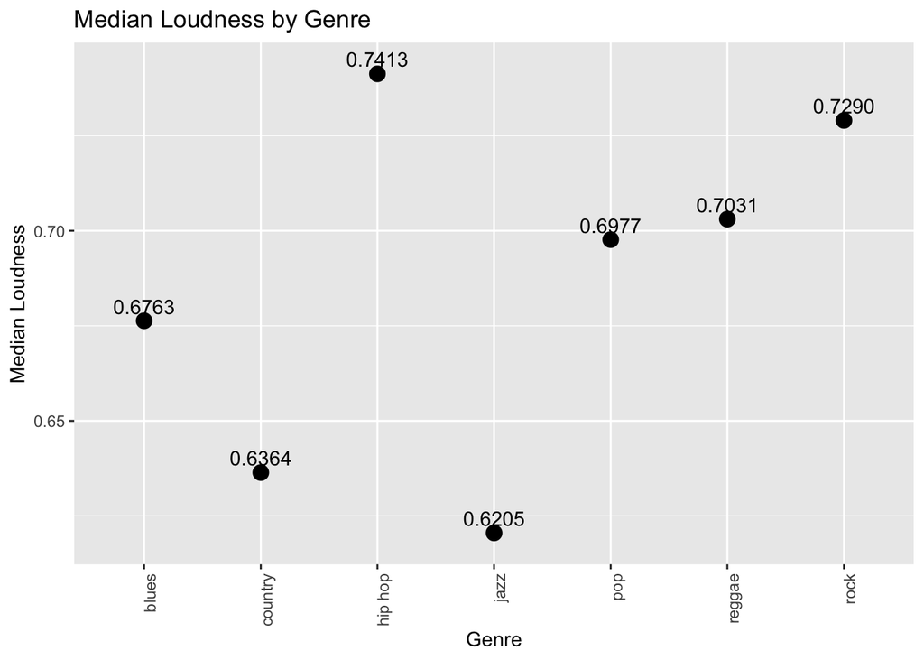

```r
library(dplyr)
library(ggplot2)

# Group data by genre, calculate median loudness
median_loudness_by_genre <- data %>%
  group_by(genre) %>%
  summarise(median_loudness = median(loudness, na.rm = TRUE)) %>%
  ungroup()

ggplot(median_loudness_by_genre, aes(x = genre, y = median_loudness)) +
  geom_dotplot(binaxis = 'y', stackdir = 'center', dotsize = 1) +
  geom_text(aes(label = sprintf("%.4f", median_loudness)), vjust = -0.5, color = "black") +
  theme(axis.text.x = element_text(angle = 90, hjust = 1)) +
  labs(title = "Median Loudness by Genre",
       x = "Genre",
       y = "Median Loudness")
```

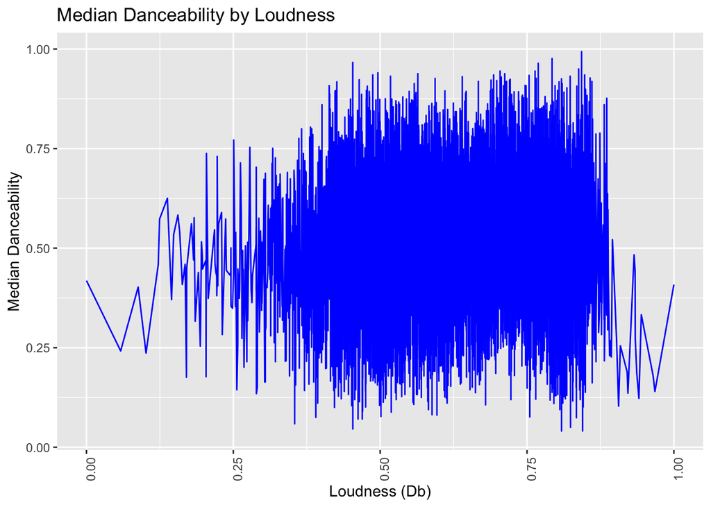

```r
library(readr)
library(ggplot2)

# Line graph of median danceability by decibel level
ggplot(median_danceability_by_loudness, aes(x = loudness, y = median_danceability)) +
  geom_line(color = "blue") +
  theme(axis.text.x = element_text(angle = 90, hjust = 1)) +
  labs(title = "Median Danceability by Loudness",
       x = "Loudness (Db)",
       y = "Median Danceability")
```

Taking a look at the line graph, we indeed find that there are many peaks in danceability beyond the .7 db mark. We also find that the highest peak in danceability lies within this range, further pointing to our predictions.

# Acousticness

Moving on to acousticness. We wanted to see how this tied into danceability.

Let’s observe it’s properties first.

```r
library(dplyr)

# Calculate median danceability by acousticness
median_danceability_by_acousticness <- data %>%
  group_by(acousticness) %>%
  summarise(median_danceability = median(danceability, na.rm = TRUE))

print(median_danceability_by_acousticness)
```

```
# A tibble: 3,786 × 2
   acousticness median_danceability
          <dbl>               <dbl>
 1  0.000000281               0.230
 2  0.000000301               0.311
 3  0.000000371               0.235
 4  0.000000432               0.281
 5  0.000000552               0.405
 6  0.000000653               0.399
 7  0.000000703               0.279
 8  0.000000733               0.389
 9  0.000000783               0.181
10  0.000000833               0.417
# ℹ 3,776 more rows
```

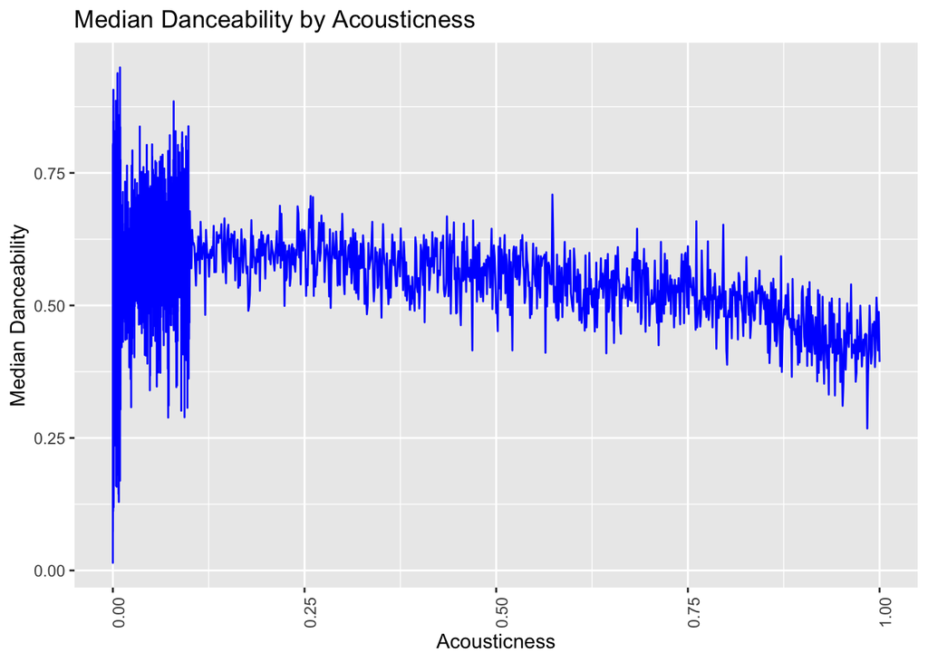

```r
library(readr)
library(ggplot2)

# Line graph of median danceability by acousticness
ggplot(median_danceability_by_acousticness, aes(x = acousticness, y = median_danceability)) +
  geom_line(color = "blue") +
  theme(axis.text.x = element_text(angle = 90, hjust = 1)) +
  labs(title = "Median Danceability by Acousticness",
       x = "Acousticness",
       y = "Median Danceability")
```

Let’s take a look at acousticness of genres.

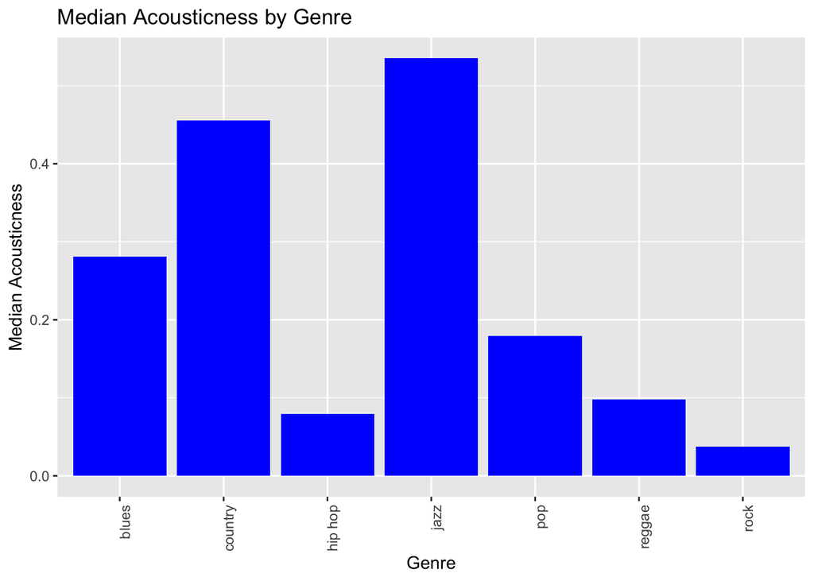

```r
library(dplyr)
library(ggplot2)

# Group data by genre, calculate median acousticness
median_acousticness_by_genre <- data %>%
  group_by(genre) %>%
  summarise(median_acousticness = median(acousticness, na.rm = TRUE)) %>%
  ungroup()

ggplot(median_acousticness_by_genre, aes(x = genre, y = median_acousticness)) +
  geom_bar(stat = "identity", fill = "blue") +
  theme(axis.text.x = element_text(angle = 90, hjust = 1)) +
  labs(title = "Median Acousticness by Genre",
       x = "Genre",
       y = "Median Acousticness")
```

# Valence

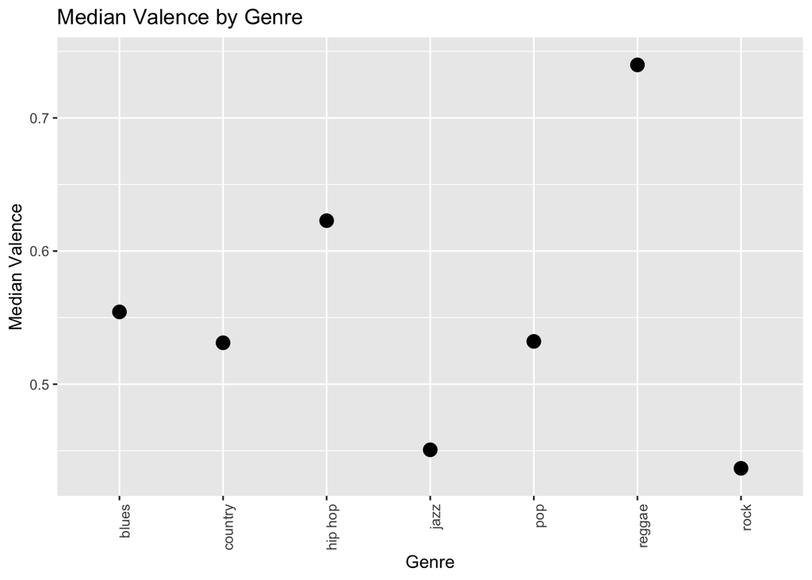

```r
library(dplyr)
library(ggplot2)

# Group data by genre, calculate median valence
median_valence_by_genre <- data %>%
  group_by(genre) %>%
  summarise(median_valence = median(valence, na.rm = TRUE)) %>%
  ungroup()

ggplot(median_valence_by_genre, aes(x = genre, y = median_valence)) +
  geom_dotplot(binaxis = 'y', stackdir = 'center', dotsize = 1) +
  theme(axis.text.x = element_text(angle = 90, hjust = 1)) +
  labs(title = "Median Valence by Genre",
       x = "Genre",
       y = "Median Valence")
```

Rock has a pitifully low score in terms of valence while our two leaders have insanely high scores. Let’s see if we can finally prove that rock isn’t danceable.

A comparison of valence and danceability could prove to be what we need.

```r
library(dplyr)

# Calculate median danceability by valence
median_danceability_by_valence <- data %>%
  group_by(valence) %>%
  summarise(median_danceability = median(valence, na.rm = TRUE))

print(median_danceability_by_valence)
```

```
# A tibble: 1,295 × 2
   valence median_danceability
     <dbl>               <dbl>
 1  0                   0
 2  0.0102              0.0102
 3  0.0103              0.0103
 4  0.0108              0.0108
 5  0.0112              0.0112
 6  0.0115              0.0115
 7  0.0117              0.0117
 8  0.0120              0.0120
 9  0.0122              0.0122
10  0.0124              0.0124
# ℹ 1,285 more rows
```

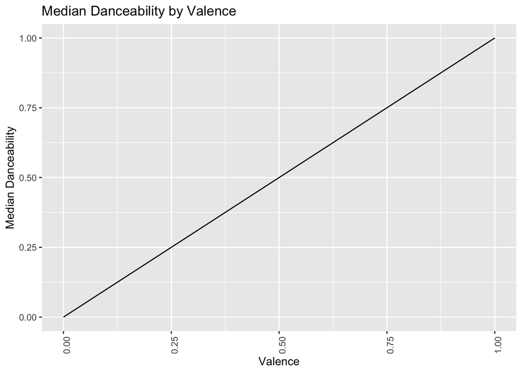

```r
library(readr)
library(ggplot2)

# Line graph of median danceability by decibel level
ggplot(median_danceability_by_valence, aes(x = valence, y = median_danceability)) +
  geom_line(color = "black") +
  theme(axis.text.x = element_text(angle = 90, hjust = 1)) +
  labs(title = "Median Danceability by Valence",
       x = "Valence",
       y = "Median Danceability")
```

Which brings us to our final variable, energy.

# Energy

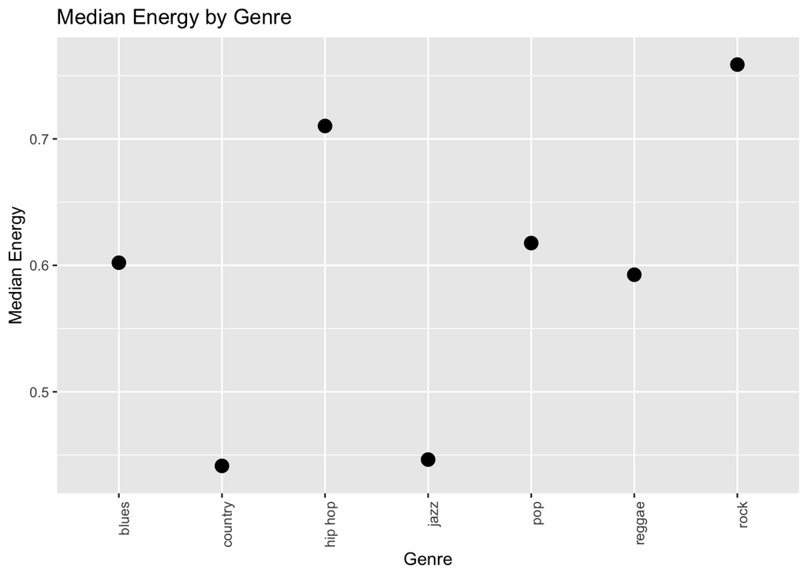

```r
# Group data by genre, calculate median feeling
median_energy_by_genre <- data %>%
  group_by(genre) %>%
  summarise(median_energy = median(energy, na.rm = TRUE)) %>%
  ungroup()

# Create a bar chart to visualize median feeling by genre
ggplot(median_energy_by_genre, aes(x = genre, y = median_energy)) +
  geom_dotplot(binaxis = 'y', stackdir = 'center', dotsize = 1) +
  theme(axis.text.x = element_text(angle = 90, hjust = 1)) +
  labs(title = "Median Energy by Genre",
       x = "Genre",
       y = "Median Energy")
```

Interestingly enough, rock is the highest energy genre, further pointing it out as the outlier from earlier. Hip hop once again outscores the rest (besides rock), with reggae seemingly lagging behind, but still maintaining a respectable energy score.

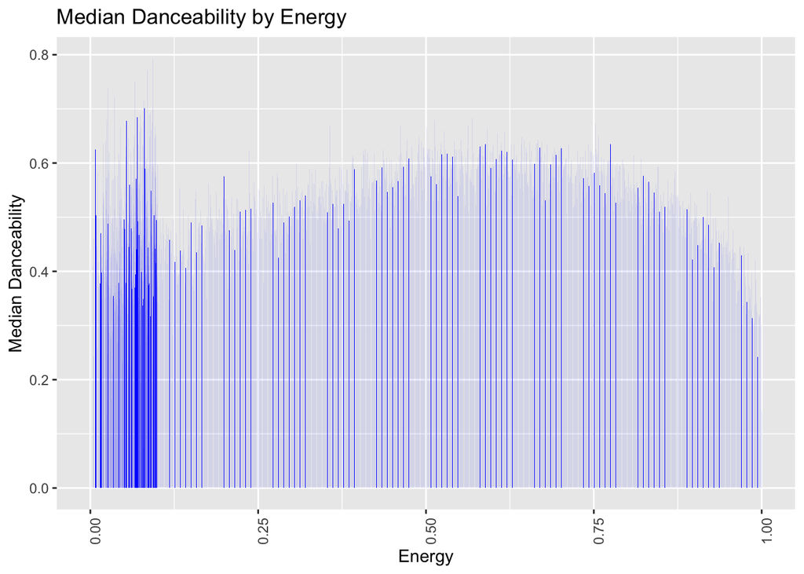

```r
library(dplyr)
library(ggplot2)

# Assuming your data frame is named 'data'

# Group data by genre, calculate median feeling
median_danceability_by_energy <- data %>%
  group_by(energy) %>%
  summarise(median_danceability = median(danceability, na.rm = TRUE)) %>%
  ungroup()

# Create a bar chart to visualize median feeling by genre
ggplot(median_danceability_by_energy, aes(x = energy, y = median_danceability)) +
  geom_bar(stat = "identity", fill = "blue") +
  theme(axis.text.x = element_text(angle = 90, hjust = 1)) +
  labs(title = "Median Danceability by Energy",
       x = "Energy",
       y = "Median Danceability")
```

However, If we take a closer look at which energy values correlate to a higher danceability we can note a few observations.

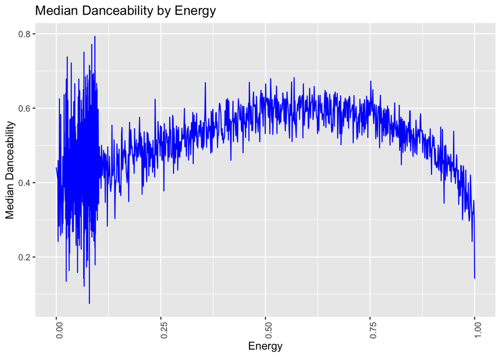

```r
# Create a bar chart to visualize median feeling by genre
ggplot(median_danceability_by_energy, aes(x = energy, y = median_danceability)) +
  geom_line(color = "blue") +
  theme(axis.text.x = element_text(angle = 90, hjust = 1)) +
  labs(title = "Median Danceability by Energy",
       x = "Energy",
       y = "Median Danceability")
```

Median danceability has high fluctuations at lower energy values, while hitting its peak. However it stabilizes at 0.25 to .75 before starkly dropping off beyond. Rock happens to have a energy value far beyond .7 showing exactly why there is a danceability dropoff. Hip hop hits the sweet spot right before the dropoff, and reggae finds itself amidst the peak values where energy is proportional to danceability. We have found statistics that show our outlier isn’t as troublesome as we thought.

## Conclusion

Danceability is an exciting song characteristic, but it is by no means the only one that can be analyzed. Additionally, “data preparation” and analyses similar to this code notebook breakdown function as a baseline for song recommendation algorthims on streaming platforms. Taking playlist data and finding matches in songs (and artists) with similar characeristics is a large part of manufacturing popularity surrounding new music.

## Works cited:

Shahane, S. (2019). Music Dataset: 1950 to 2019 [Data set]. Kaggle. https://www.kaggle.com/datasets/saurabhshahane/music-dataset-1950-to-2019/data

Misael, L., Forster, C., Fontelles, E., Sampaio, V., & França, M. (2020, October). Temporal analysis and visualisation of music. In Anais do XVII Encontro Nacional de Inteligência Artificial e Computacional (pp. 507-518). SBC.